# HW2

Ting Huang

Tuesday, January 26, 2016

# Problem 1

## (a)

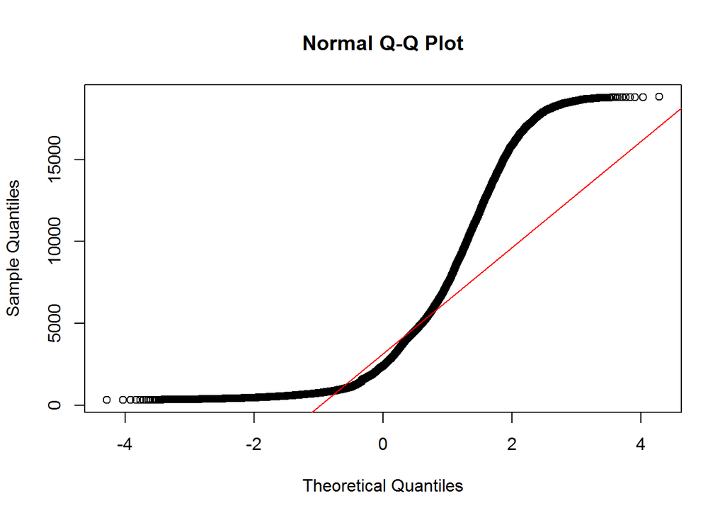

```r
library(ggplot2)
data(diamonds)
qqnorm(diamonds$price);
qqline(diamonds$price, col = 2)
```

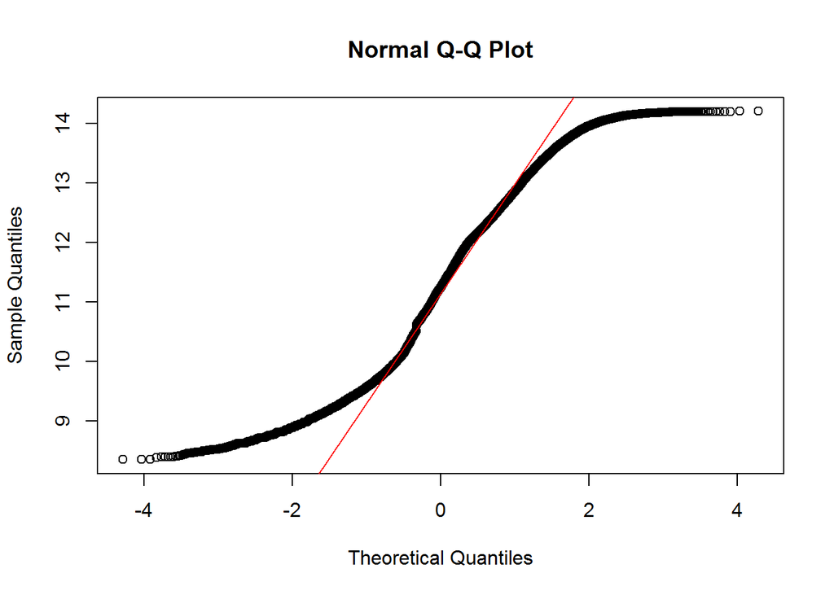

```r
log2Price<-log2(diamonds$price)
qqnorm(log2Price);
qqline(log2Price, col = 2)
```

The qqplot before log2 transformation clearly shows that this distribution is not normal. The plot is “extremely heavy” at each end of the tail. It curves away from the line at each end in opposite directions quickly.

## (b)

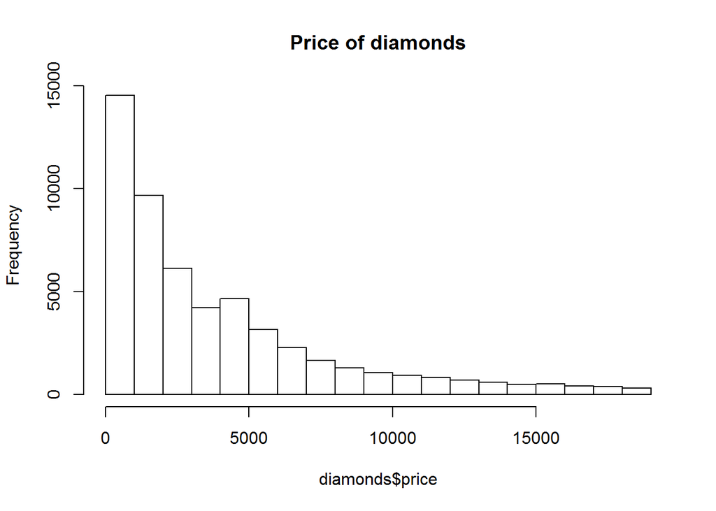

```r
library(ggplot2)
data(diamonds)
hist(diamonds$price,main="Price of diamonds");
```

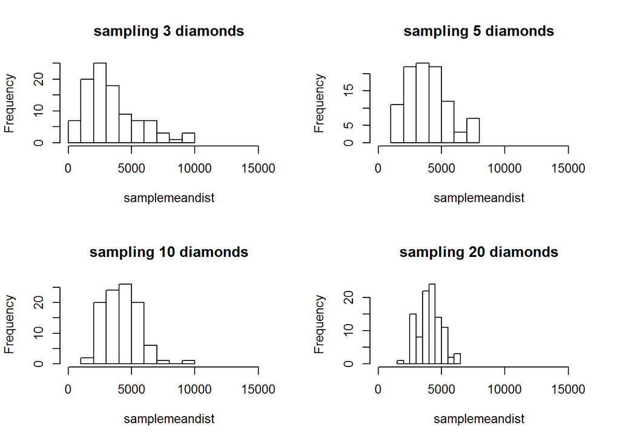

```r
par(mfrow = c(2,2))
sampleSize <- c(3,5,10,20)
replications<-100
for (i in 1:length(sampleSize)) {
  ndiamonds<-nrow(diamonds)
  samplemeandist<-NULL
  for(j in 1:replications){
    samples<-sample(1:ndiamonds, sampleSize[i], replace = FALSE)
    samplemean<-mean(diamonds[samples,"price"])
    samplemeandist<-c(samplemeandist,samplemean)
  }
hist(samplemeandist,xlim=c(0,16000),main=paste("sampling",sampleSize[i],"diamonds"))
}
```

Sample mean distribution becomes more central to the population mean as the sample size increases.

The sampling distribution of mean price get narrower and have more of a bell shape as the sample size increases.

Although the population distribution is not normal, the distribution of sample mean becomes more normal as the sample size increases.

## (c)

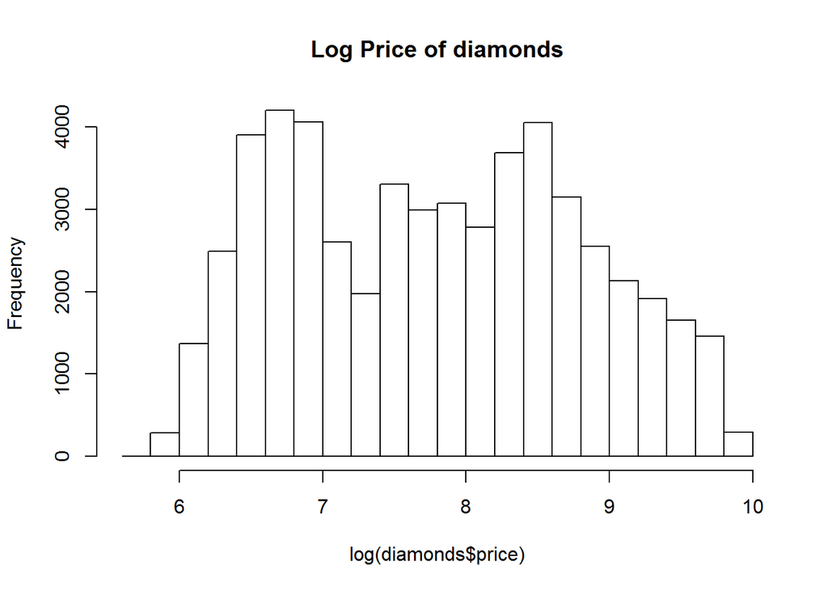

```r
library(ggplot2)
data(diamonds)
hist(log(diamonds$price),main="Log Price of diamonds");
```

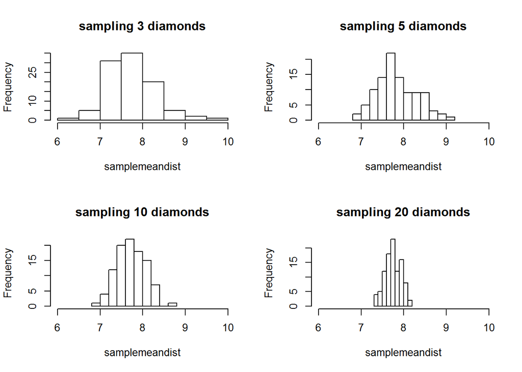

```r
par(mfrow = c(2,2))
sampleSize <- c(3,5,10,20)
replications<-100
for (i in 1:length(sampleSize)) {
  ndiamonds<-nrow(diamonds)
  samplemeandist<-NULL
  for(j in 1:replications){
    samples<-sample(1:ndiamonds, sampleSize[i], replace = FALSE)
    samplemean<-mean(log(diamonds[samples,"price"]))
    samplemeandist<-c(samplemeandist,samplemean)
  }
hist(samplemeandist,xlim=c(6,10),main=paste("sampling",sampleSize[i],"diamonds"))
}
```

Similar observation as that in the raw diamond price data.

# Problem 2

## (a)

The sampling distribution of sample mean height is $N(\mu=65in, \sigma=0.5in)$.

## (b)

```r
#more than 66in
pnorm(66,mean = 65,sd = 0.5,lower.tail = FALSE)
```

```
## [1] 0.02275013
```

```r
#less than 63in
pnorm(63,mean = 65,sd = 0.5)
```

```
## [1] 3.167124e-05
```

```r
#between 63.5in and 66.5in
pnorm(66.5,mean = 65,sd = 0.5)-pnorm(63.5,mean = 65,sd = 0.5)
```

```
## [1] 0.9973002
```

## (c)

```r
cat("The lower limit is ",qnorm(0.025,mean = 65,sd = 0.5))
```

```
## The lower limit is  64.02002
```

```r
cat("The upper limit is ",qnorm(0.025,mean = 65,sd = 0.5,lower.tail = FALSE))
```

```
## The upper limit is  65.97998
```

## (d)

```r
pnorm(66,mean = 65,sd = 2.5,lower.tail = FALSE)
```

```
## [1] 0.3445783
```

## (e)

For (b), the distribution is the sampling distribution of sample mean height.

For (d), the distribution is the population distribution.

# Problem 3

## (a)

The sampling distribution of sample mean height is $N(\mu=65in, \sigma=0.25in)$.

## (b)

```r
#more than 66in
pnorm(66,mean = 65,sd = 0.25,lower.tail = FALSE)
```

```
## [1] 3.167124e-05
```

```r
#less than 63in
pnorm(63,mean = 65,sd = 0.25)
```

```
## [1] 6.220961e-16
```

```r
#between 63.5in and 66.5in
pnorm(66.5,mean = 65,sd = 0.25)-pnorm(63.5,mean = 65,sd = 0.25)
```

```
## [1] 1
```

## (c)

```r
cat("The lower limit is ",qnorm(0.025,mean = 65,sd = 0.25))
```

```
## The lower limit is  64.51001
```

```r
cat("The upper limit is ",qnorm(0.025,mean = 65,sd = 0.25,lower.tail = FALSE))
```

```
## The upper limit is  65.48999
```

## (d)

```r
pnorm(66,mean = 65,sd = 2.5,lower.tail = FALSE)
```

```
## [1] 0.3445783
```

## (e)

For (b), the distribution is the sampling distribution of sample mean height.

For (d), the distribution is the population distribution.

# Problem 4

The standard deviation is the standard deviation of the population.

The standard error is the standard deviation of the sampling distribution of sample mean.

For a given population distribution, the standard deviation is larger and the standard error is smaller.

# Problem 5

The larger the sample size is, the smaller the standard error is.

# Problem 6

Central Limit Theorem: Y is a random variable with population mean $\mu$ and standard deviation $\sigma$. $\bar{y}_n$ is the sample mean with sample size $n$.

1. $\mu_{\bar{y}_n}=\mu$ and $\sigma_{\bar{y}_n}=\frac{\sigma}{\sqrt{n}}$. As $n$ increases, $\sigma_{\bar{y}_n}$ becomes smaller and the sampling distribution is narrowing down.
2. If $Y\sim N(\mu,\sigma)$, then $\bar{y}_n\sim N(\mu,\frac{\sigma}{\sqrt{n}})$.
3. If $Y\neq N(\mu,\sigma)$, then $\bar{y}_n\sim^{approx} N(\mu,\frac{\sigma}{\sqrt{n}})$.

Importance: CLT says that a normal distribution arises regardless of the initial distribution. Even if our population has a skewed distribution, a sampling distribution for a sample with a sufficiently large sample size will be normal. The use of an appropriate sample size and CLT help us to get around the problem of data from populations that are not normal.